# ASSIGNMENT-7

RUTHRESHWARAN M

2023-05-4

```r
library(haven)
datatibble1 <- read_sav("Raw/chap8data.sav")
datatibble1
```

```
## # A tibble: 21,981 × 13
##    voice1        jobsat1 jobsat2 jobsat3 jobsat4 jobsat5 jobsat6 jobsat7 jobsat8
##    <dbl+lbl>     <dbl+l> <dbl+l> <dbl+l> <dbl+l> <dbl+l> <dbl+l> <dbl+l> <dbl+l>
##  1 5 [strongly … 2 [dis… 2 [dis… 2 [dis… 4 [sat… 2 [dis… 2 [dis… 4 [sat… 3 [nei…
##  2 3 [neither a… 4 [sat… 4 [sat… 4 [sat… 3 [nei… 3 [nei… 3 [nei… 4 [sat… 4 [sat…
##  3 4 [agree]     4 [sat… 3 [nei… 4 [sat… 3 [nei… 3 [nei… 3 [nei… 4 [sat… 4 [sat…
##  4 4 [agree]     4 [sat… 4 [sat… 4 [sat… 3 [nei… 3 [nei… 4 [sat… 4 [sat… 4 [sat…
##  5 4 [agree]     4 [sat… 5 [ver… 4 [sat… 3 [nei… 4 [sat… 4 [sat… 4 [sat… 4 [sat…
##  6 5 [strongly … 3 [nei… 3 [nei… 3 [nei… 3 [nei… 3 [nei… 2 [dis… 3 [nei… 3 [nei…
##  7 2 [disagree]  4 [sat… 4 [sat… 4 [sat… 2 [dis… 3 [nei… 4 [sat… 3 [nei… 4 [sat…
##  8 5 [strongly … 4 [sat… 5 [ver… 4 [sat… 4 [sat… 4 [sat… 4 [sat… 5 [ver… 4 [sat…
##  9 2 [disagree]  4 [sat… 4 [sat… 4 [sat… 3 [nei… 2 [dis… 4 [sat… 4 [sat… 4 [sat…
## 10 4 [agree]     3 [nei… 3 [nei… 3 [nei… 4 [sat… 5 [ver… 2 [dis… 3 [nei… 4 [sat…
## # ℹ 21,971 more rows
## # ℹ 4 more variables: jobsatcomp <dbl+lbl>, voice2 <dbl+lbl>, voice3 <dbl+lbl>,
## #   voice4 <dbl+lbl>
```

```r
freq_table <- table(datatibble1$jobsatcomp)
freq_table
```

```
##
##     1 1.125  1.25 1.375   1.5 1.625  1.75 1.875     2 2.125  2.25 2.375   2.5
##    36    22    38    43    77    73    94   119   168   223   299   379   439
## 2.625  2.75 2.875     3 3.125  3.25 3.375   3.5 3.625  3.75 3.875     4 4.125
##   501   598   711   869  1041  1066  1202  1437  1546  1673  1549  1839  1027
##  4.25 4.375   4.5 4.625  4.75 4.875     5
##   873   704   568   446   370   285   351
```

```r
summary(datatibble1$jobsatcomp)
```

```
##    Min. 1st Qu.  Median    Mean 3rd Qu.    Max.    NA's
##   1.000   3.125   3.625   3.555   4.000   5.000    1315
```

```r
freq_table1 <- table(datatibble1$voice1)
freq_table1
```

```
##
##    1    2    3    4    5
## 1247 3245 5247 9204 2574
```

```r
summary(datatibble1$voice1)
```

```
##    Min. 1st Qu.  Median    Mean 3rd Qu.    Max.    NA's
##     1.0     3.0     4.0     3.4     4.0     5.0     464
```

```r
library(psych)

describe(datatibble1$jobsatcomp)
```

```
##    vars     n mean   sd median trimmed  mad min max range  skew kurtosis   se
## X1    1 20666 3.55 0.72   3.62    3.55 0.74   1   5     4 -0.51     0.32 0.01
```

```r
describe(datatibble1$voice1)
```

```
##    vars     n mean   sd median trimmed  mad min max range  skew kurtosis   se
## X1    1 21517  3.4 1.06      4     3.4 1.48   1   5     4 -0.54    -0.37 0.01
```

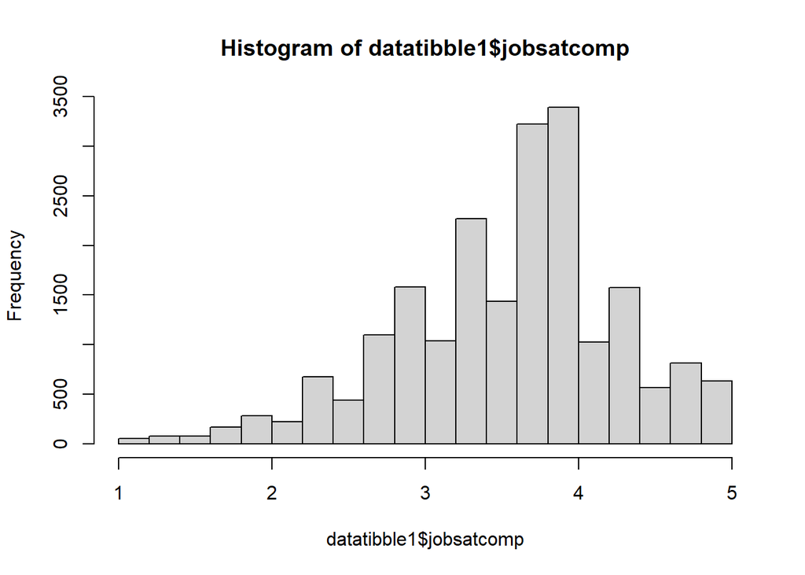

```r
hist(datatibble1$jobsatcomp)
```

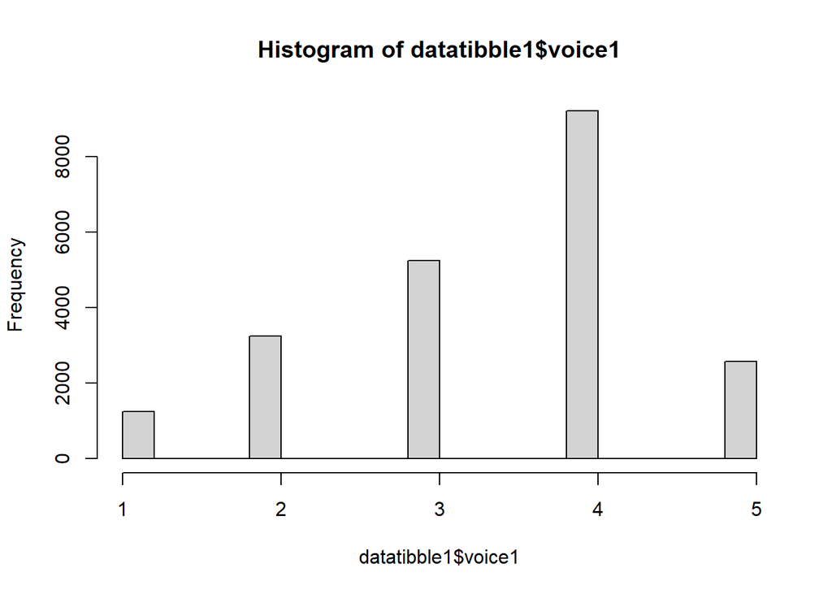

```r
hist(datatibble1$voice1)
```

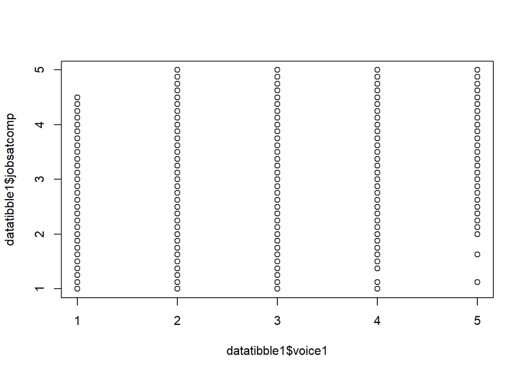

```r
plot(datatibble1$voice1, datatibble1$jobsatcomp)
```

```r
cor(datatibble1$voice1, datatibble1$jobsatcomp, method = "pearson", use = "complete.obs")
```

```
## [1] 0.5792044
```

```r
cor.test(datatibble1$voice1, datatibble1$jobsatcomp, method = "pearson")
```

```
##
##  Pearson's product-moment correlation
##
## data:  datatibble1$voice1 and datatibble1$jobsatcomp
## t = 101.33, df = 20337, p-value < 2.2e-16
## alternative hypothesis: true correlation is not equal to 0
## 95 percent confidence interval:
##  0.5699985 0.5882650
## sample estimates:
##       cor
## 0.5792044
```

```r
library(tidyverse)
```

```
## ✖ ggplot2::%+%()   masks psych::%+%()
```

```r
datatibble2 <- tibble(datatibble1$jobsatcomp)

datatibble2$voice1 <- datatibble1$voice1
datatibble2$voice2 <- datatibble1$voice2
datatibble2$voice3 <- datatibble1$voice3
datatibble2$voice4 <- datatibble1$voice4

datatibble2
```

```
## # A tibble: 21,981 × 5
##    `datatibble1$jobsatcomp` voice1                      voice2  voice3  voice4
##    <dbl+lbl>                <dbl+lbl>                   <dbl+l> <dbl+l> <dbl+lb>
##  1 2.62                     5 [strongly agree]          4 [goo… 4 [goo…  4 [goo…
##  2 3.62                     3 [neither agree nor disag… 3 [nei… 3 [nei…  3 [nei…
##  3 3.5                      4 [agree]                   4 [goo… 4 [goo…  4 [goo…
##  4 3.75                     4 [agree]                   3 [nei… 3 [nei…  3 [nei…
##  5 4 [satisfied]            4 [agree]                   5 [ver… 4 [goo…  4 [goo…
##  6 2.88                     5 [strongly agree]          3 [nei… 3 [nei…  3 [nei…
##  7 3.5                      2 [disagree]                3 [nei… 3 [nei…  3 [nei…
##  8 4.25                     5 [strongly agree]          5 [ver… 5 [ver…  5 [ver…
##  9 3.62                     2 [disagree]                3 [nei… 3 [nei…  4 [goo…
## 10 3.38                     4 [agree]                   3 [nei… 4 [goo… NA
## # ℹ 21,971 more rows
```

```r
cor(datatibble2, use="complete.obs")
```

```
##                        datatibble1$jobsatcomp    voice1    voice2    voice3
## datatibble1$jobsatcomp              1.0000000 0.5848964 0.5707549 0.5864359
## voice1                              0.5848964 1.0000000 0.6957840 0.7101269
## voice2                              0.5707549 0.6957840 1.0000000 0.8308380
## voice3                              0.5864359 0.7101269 0.8308380 1.0000000
## voice4                              0.5768684 0.6740096 0.7766166 0.8389089
##                           voice4
## datatibble1$jobsatcomp 0.5768684
## voice1                 0.6740096
## voice2                 0.7766166
## voice3                 0.8389089
## voice4                 1.0000000
```

```r
library(rstatix)
library(tidyverse)

cor_mat1 <- cor_mat(datatibble2)
cor_mat1
```

```
## # A tibble: 5 × 6
##   rowname                `datatibble1$jobsatcomp` voice1 voice2 voice3 voice4
## * <chr>                                     <dbl>  <dbl>  <dbl>  <dbl>  <dbl>
## 1 datatibble1$jobsatcomp                     1      0.58   0.57   0.58   0.58
## 2 voice1                                     0.58   1      0.69   0.71   0.67
## 3 voice2                                     0.57   0.69   1      0.83   0.78
## 4 voice3                                     0.58   0.71   0.83   1      0.84
## 5 voice4                                     0.58   0.67   0.78   0.84   1
```

```r
cor_mat1 %>% cor_get_pval()
```

```
## # A tibble: 5 × 6
##   rowname                `datatibble1$jobsatcomp` voice1 voice2 voice3 voice4
##   <chr>                                     <dbl>  <dbl>  <dbl>  <dbl>  <dbl>
## 1 datatibble1$jobsatcomp                        0      0      0      0      0
## 2 voice1                                        0      0      0      0      0
## 3 voice2                                        0      0      0      0      0
## 4 voice3                                        0      0      0      0      0
## 5 voice4                                        0      0      0      0      0
```

Simple Linear Regression:

```r
datatibble3 <- datatibble1 %>%
  filter(!is.na(voice1))


model <- lm(datatibble3$jobsatcomp ~ datatibble3$voice1)
model
```

```
##
## Call:
## lm(formula = datatibble3$jobsatcomp ~ datatibble3$voice1)
##
## Coefficients:
##        (Intercept)  datatibble3$voice1
##             2.2148              0.3941
```

```r
summary(model)
```

```
##
## Call:
## lm(formula = datatibble3$jobsatcomp ~ datatibble3$voice1)
##
## Residuals:
##      Min       1Q   Median       3Q      Max
## -3.06045 -0.37808  0.06455  0.37192  1.99692
##
## Coefficients:
##                    Estimate Std. Error t value Pr(>|t|)
## (Intercept)         2.21483    0.01387   159.7   <2e-16 ***
## datatibble3$voice1  0.39413    0.00389   101.3   <2e-16 ***
## ---
## Signif. codes:  0 '***' 0.001 '**' 0.01 '*' 0.05 '.' 0.1 ' ' 1
##
## Residual standard error: 0.5881 on 20337 degrees of freedom
##   (1178 observations deleted due to missingness)
## Multiple R-squared:  0.3355, Adjusted R-squared:  0.3354
## F-statistic: 1.027e+04 on 1 and 20337 DF,  p-value: < 2.2e-16
```

```r
datatibble4 <- datatibble1 %>%
  filter(!is.na(voice2))


model1 <- lm(datatibble4$jobsatcomp ~ datatibble4$voice2)
model1
```

```
##
## Call:
## lm(formula = datatibble4$jobsatcomp ~ datatibble4$voice2)
##
## Coefficients:
##        (Intercept)  datatibble4$voice2
##             2.3708              0.3596
```

```r
summary(model1)
```

```
##
## Call:
## lm(formula = datatibble4$jobsatcomp ~ datatibble4$voice2)
##
## Residuals:
##      Min       1Q   Median       3Q      Max
## -2.91878 -0.33998  0.05042  0.41002  2.26962
##
## Coefficients:
##                    Estimate Std. Error t value Pr(>|t|)
## (Intercept)        2.370777   0.012815  185.00   <2e-16 ***
## datatibble4$voice2 0.359600   0.003682   97.65   <2e-16 ***
## ---
## Signif. codes:  0 '***' 0.001 '**' 0.01 '*' 0.05 '.' 0.1 ' ' 1
##
## Residual standard error: 0.596 on 20233 degrees of freedom
##   (1182 observations deleted due to missingness)
## Multiple R-squared:  0.3203, Adjusted R-squared:  0.3203
## F-statistic:  9536 on 1 and 20233 DF,  p-value: < 2.2e-16
```

```r
datatibble5 <- datatibble1 %>%
  filter(!is.na(voice3))


model2 <- lm(datatibble5$jobsatcomp ~ datatibble5$voice3)
model2
```

```
##
## Call:
## lm(formula = datatibble5$jobsatcomp ~ datatibble5$voice3)
##
## Coefficients:
##        (Intercept)  datatibble5$voice3
##              2.354               0.377
```

```r
summary(model2)
```

```
##
## Call:
## lm(formula = datatibble5$jobsatcomp ~ datatibble5$voice3)
##
## Residuals:
##      Min       1Q   Median       3Q      Max
## -2.86232 -0.36028  0.01472  0.38972  2.26881
##
## Coefficients:
##                    Estimate Std. Error t value Pr(>|t|)
## (Intercept)        2.354142   0.012550   187.6   <2e-16 ***
## datatibble5$voice3 0.377045   0.003719   101.4   <2e-16 ***
## ---
## Signif. codes:  0 '***' 0.001 '**' 0.01 '*' 0.05 '.' 0.1 ' ' 1
##
## Residual standard error: 0.5885 on 19956 degrees of freedom
##   (1127 observations deleted due to missingness)
## Multiple R-squared:   0.34,  Adjusted R-squared:   0.34
## F-statistic: 1.028e+04 on 1 and 19956 DF,  p-value: < 2.2e-16
```

```r
datatibble6 <- datatibble1 %>%
  filter(!is.na(voice4))


model3 <- lm(datatibble6$jobsatcomp ~ datatibble6$voice4)
model3
```

```
##
## Call:
## lm(formula = datatibble6$jobsatcomp ~ datatibble6$voice4)
##
## Coefficients:
##        (Intercept)  datatibble6$voice4
##             2.4356              0.3784
```

```r
summary(model3)
```

```
##
## Call:
## lm(formula = datatibble6$jobsatcomp ~ datatibble6$voice4)
##
## Residuals:
##      Min       1Q   Median       3Q      Max
## -2.94926 -0.32426  0.05074  0.42915  2.18597
##
## Coefficients:
##                    Estimate Std. Error t value Pr(>|t|)
## (Intercept)        2.435621   0.012177  200.02   <2e-16 ***
## datatibble6$voice4 0.378409   0.003872   97.73   <2e-16 ***
## ---
## Signif. codes:  0 '***' 0.001 '**' 0.01 '*' 0.05 '.' 0.1 ' ' 1
##
## Residual standard error: 0.5956 on 19275 degrees of freedom
##   (1022 observations deleted due to missingness)
## Multiple R-squared:  0.3313, Adjusted R-squared:  0.3313
## F-statistic:  9552 on 1 and 19275 DF,  p-value: < 2.2e-16
```

Summary:

Pearson’s r and Simple Regression:

These are two ways of expressing the nature of the relationship between X and Y when both variables are ordinal or preferably scale level. Both test are used when the relationship between the dependent and independent variable is linear. The result of both test is the coefficient.

In the case of Pearson’s r, the coefficient is standardized between -1 and +1. In the case of a simple regression, it is Beta or the independent variable’s coefficient.

In both test, a positive coefficient implies a positive relationship between X and Y. So, as values in X increase, so do values in Y. A negative coefficient implies a negative relationship between X and Y. So as values in X increase, values in Y simultaneously decrease. Here, we cannot say that X causes Y, but we can conclude that X is associated with Y (or correlated with Y) provided that the p-value attached to these coefficients is < 0.05.

The lower the p-value, the more confident we are that the positive or negative relationship we found generalizes to the population. If the coefficients equal to approximately zero, then the p-value will very likely be non significant which will imply that there is no linear relationship between X and Y. i.e., we would be unable to make that quantum leap from the sample to the population.

But in real time, there are more than one variable is associated with Y. So to model real-life relationships, bivariate correlations are not enough because real life is more complex. So we need to use multivariate tests. Some of them are multiple regression, logistic regression, factor analysis, structural equation modelling.